# Integer Programming

Complete the IP Programming problem that we started in class. What is the final solution. The final solution should have both X1 and X2 as integers, and an objective function value. The problem formulation is

```
max: 8 x1 + 5 x2;
s.t
  x1 + x2 <= 6;
  9 x1 + 5 x2 <= 45;
  int: x1, x2
```

In addition, your output file should contain the visualization of the solution. Choose any or all parts of the solution, for example the objective function, variable values, etc. But, the visualization should clearly identify the final optimal solution, both variable values and objective function value.

Let’s load necessary libraries

```r
library("lpSolveAPI")
library("magrittr")
library("igraph")
# Checks if a number is an integer
is_int <- function(n) {
    return(as.integer(n) == n)
}

# Given a vector of numeric elements
# Return the maximum non integer solution
branch_on <- function(sols) {
    non_ints <- subset(sols, !is_int(sols))

    if (length(non_ints) == 0) {
        return(0)
    }

    return(max(non_ints))
}

# Get the name of descision variable from the bounded solution
get.branch_name <- function(bounded_sol, branch_val) {
    return(bounded_sol %>% names() %>% extract(match(branch_val, bounded_sol)))
}

get.branch_vec <- function(branch_name) {
    switch(branch_name,
        "x1" = c(1, 0),
        "x2" = c(0, 1),
        c(0, 0) # default case
    )
}

fmt <- function(sol) {
    return(sprintf(
        "Z = %.2f\nx1 = %.2f\nx2 = %.2f",
        sol[c("z")],
        sol[c("x1")],
        sol[c("x2")])
    )
}
```

Let’s create create the problem formulation and assign it to a variable called `ip_prob`

```r
ip_prob <- make.lp(0, 2) %T>%
    lp.control(sense = "max") %T>%
    set.objfn(c(8, 5)) %T>%
    add.constraint(c(1, 1), "<=", 6) %T>%
    add.constraint(c(9, 5), "<=", 45)

ip_prob
```

```
## Model name:
##             C1    C2
## Maximize     8     5
## R1           1     1  <=   6
## R2           9     5  <=  45
## Kind       Std   Std
## Type      Real  Real
## Upper      Inf   Inf
## Lower        0     0
```

```r
solve(ip_prob)
```

```
## [1] 0
```

```r
get.objective(ip_prob)
```

```
## [1] 41.25
```

```r
get.variables(ip_prob)
```

```
## [1] 3.75 2.25
```

`ub_sol` represents the upper bound solution of the ip problem `ip_prob`

```r
ub_sol <- c(z = get.objective(ip_prob), x = get.variables(ip_prob))

ub_sol
```

```
##     z    x1    x2
## 41.25  3.75  2.25
```

We will create the graph object and then add the first `ub_sol` as the root

```r
root <- fmt(ub_sol)
G <- make_tree(0, 2) + vertex(root)
```

In order to solve this ip problem, we will use the branch and bound algorithm. I have written a recursive function named `branch_bound` that will execute the steps of the algorithm automatically as well as output the visual representation of the algorithm.

```r
branch_bound <- function(upper_bound, ip_prob, graph, root) {
    print(
        fmt(upper_bound) %>%
        sprintf("Given Soltuion %s ", .) %>%
        gsub("\n", " ", .)
    )

    branch_val <- upper_bound %>% extract(c("x1", "x2")) %>% branch_on()

    if (branch_val == 0) {
        print(
            fmt(upper_bound) %>%
            sprintf("Final Solution %s ", .) %>%
            gsub("\n", " ", .)
        )
        plot(graph,
            layout = layout.reingold.tilford(graph),
            vertex.size = 50,
            edge.label.cex = 0.7,
            vertex.label.cex = 0.7,
            vertex.shape = "circle"
        )
        return(ip_prob)
    }

    branch_var <- get.branch_name(upper_bound, branch_val)
    branch_vec <- get.branch_vec(branch_var)
    var_floored <- floor(branch_val)
    var_ceiled <- ceiling(branch_val)

    print(sprintf("Branching On %s = %g", branch_var, branch_val))

    # Left Side
    left_ip_prob <- ip_prob %T>% add.constraint(branch_vec, "<=", var_floored)
    left_status <- solve(left_ip_prob)

    print(sprintf("Left Side Status: %s", ifelse(left_status == 0, "Optimal Solutin Found!", "Infeasible")))

    left_ub_sol <- c(
        z = get.objective(left_ip_prob),
        x = get.variables(left_ip_prob)
    )

    left_node <- if (left_status == 0) fmt(left_ub_sol) else "Infeasible"
    left_label <- sprintf("%s <= %d", branch_var, var_floored)
    graph <- graph +
        vertex(left_node) +
        edge(root, left_node, label = left_label)

    # Remove the last constraint added for the left side of the branch
    left_ip_prob %>%
        get.constraints() %>%
        length() %>%
        delete.constraint(left_ip_prob, .)

    print(
        fmt(left_ub_sol) %>%
        sprintf("Left side upper bound solution: %s ", .) %>%
        gsub("\n", " ", .)
    )

    # Right Side
    right_ip_prob <- ip_prob %T>% add.constraint(branch_vec, ">=", var_ceiled)
    right_status <- solve(right_ip_prob)

    print(sprintf("Right Side Status: %s", ifelse(right_status == 0, "Optimal Solutin Found!", "Infeasible")))

    right_ub_sol <- c(
        z = get.objective(right_ip_prob),
        x = get.variables(right_ip_prob)
    )

    right_node <- if (right_status == 0) fmt(right_ub_sol) else "Infeasible"
    right_label <- sprintf("%s >= %d", branch_var, var_ceiled)
    graph <- graph +
        vertex(right_node) +
        edge(root, right_node, label = right_label)

    # Remove the last constraint added for the right side of the branch
    right_ip_prob %>%
        get.constraints() %>%
        length() %>%
        delete.constraint(right_ip_prob, .)

    print(
        fmt(right_ub_sol) %>%
        sprintf("Right side upper bound solution: %s ", .) %>%
        gsub("\n", " ", .)
    )

    if (left_status == 0 && right_status == 0) {
        if (left_ub_sol[c("z")] > right_ub_sol[c("z")]) {
            left_ip_prob <- ip_prob %T>%
                add.constraint(branch_vec, "<=", var_floored)

            branch_bound(left_ub_sol, left_ip_prob, graph, left_node)
        } else {
            right_ip_prob <- ip_prob %T>%
                add.constraint(branch_vec, ">=", var_ceiled)

            branch_bound(right_ub_sol, right_ip_prob, graph, right_node)
        }
    }
    else if (left_status == 0 && right_status != 0) {
        left_ip_prob <- ip_prob %T>%
            add.constraint(branch_vec, "<=", var_floored)

        branch_bound(left_ub_sol, left_ip_prob, graph, left_node)
    }
    else if (left_status != 0 && right_status == 0) {
        right_ip_prob <- ip_prob %T>%
            add.constraint(branch_vec, ">=", var_ceiled)

        branch_bound(right_ub_sol, right_ip_prob, graph, right_node)
    }
    else {
        print("Infeasible")
        return(ip_prob)
    }
}
```

```r
branch_bound(ub_sol, ip_prob, G, root)
```

```
## [1] "Given Soltuion Z = 41.25 x1 = 3.75 x2 = 2.25 "
## [1] "Branching On x1 = 3.75"
## [1] "Left Side Status: Optimal Solutin Found!"
## [1] "Left side upper bound solution: Z = 39.00 x1 = 3.00 x2 = 3.00 "
## [1] "Right Side Status: Optimal Solutin Found!"
## [1] "Right side upper bound solution: Z = 41.00 x1 = 4.00 x2 = 1.80 "
## [1] "Given Soltuion Z = 41.00 x1 = 4.00 x2 = 1.80 "
## [1] "Branching On x2 = 1.8"
## [1] "Left Side Status: Optimal Solutin Found!"
## [1] "Left side upper bound solution: Z = 40.56 x1 = 4.44 x2 = 1.00 "
## [1] "Right Side Status: Infeasible"
## [1] "Right side upper bound solution: Z = -1000000000000000019884624838656.00 x1 = 4.44 x2 = 1.00 "
## [1] "Given Soltuion Z = 40.56 x1 = 4.44 x2 = 1.00 "
## [1] "Branching On x1 = 4.44444"
## [1] "Left Side Status: Optimal Solutin Found!"
## [1] "Left side upper bound solution: Z = 37.00 x1 = 4.00 x2 = 1.00 "
## [1] "Right Side Status: Optimal Solutin Found!"
## [1] "Right side upper bound solution: Z = 40.00 x1 = 5.00 x2 = 0.00 "
## [1] "Given Soltuion Z = 40.00 x1 = 5.00 x2 = 0.00 "
## [1] "Final Solution Z = 40.00 x1 = 5.00 x2 = 0.00 "
```

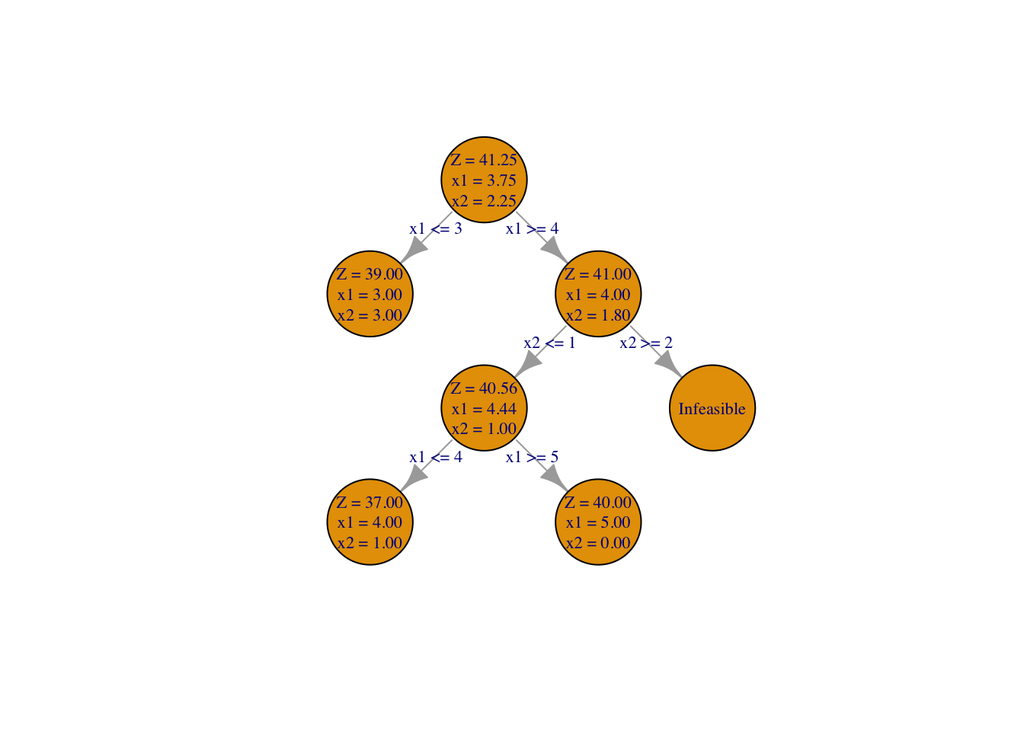

```
## Model name:
##             C1    C2
## Maximize     8     5
## R1           1     1  <=   6
## R2           9     5  <=  45
## R3           1     0  >=   4
## R4           0     1  <=   1
## R5           1     0  >=   5
## Kind       Std   Std
## Type      Real  Real
## Upper      Inf   Inf
## Lower        0     0
```